# Model Selection for airdryer Data with Explanations

2022-03-25

First we need to upload the data. So:

```r
df_airdryer = read.csv('E:/2022/Freelance/Jobs/001-25/data-airdryer.csv', header=T)
df_airdryer = data.frame(time=df_airdryer$Time..hours., fails=df_airdryer$Number.of.failures)
```

So we created a new data frame with proper column names. To see what it looks like, we can print the data frame:

```r
df_airdryer
```

```
##    time fails
## 1  2000     0
## 2  2300     0
## 3  2600     1
## 4  2740     2
## 5  2830     1
## 6  2900     1
## 7  2990     3
## 8  3140     1
## 9  3200     1
## 10 3320     2
## 11 3420     2
## 12 3480     1
## 13 3500     2
## 14 3560     2
```

[output cut: 30 more lines]

In the second column the number of failures for each time points is recorded. In order to have a complete data set we need to create repetitions of those time points with the frequency of the number of failures. Therefore we repeat each time points relative to their respective number of failures.

```r
time_rep = rep(df_airdryer$time, df_airdryer$fails)
```

Now we create an empty data frame to hold the information of the distributions that we are going to check.

```r
info_df = data.frame(model=NA, method=NA,Log_likelihood=NA, AIC=NA)
```

In this data frame we have a *model* column which stores the name of the distribution (weibull, gamma, log-normal, beta), a *method* column which stores the method of optimization that is going to be used (mle, mme, qme, mge), and *log-likelihood* and *aic* columns.

Before doing anything, we need to call a library called *fitdistrplus* that will do this process for us. After that we can start checking different distributions with the `fitdist` function.

```r
library(fitdistrplus)
```

# Weibull Distribution

## Weibull with mle

our first method is mle (maximum likelihood estimation):

```r
fit_wei_mle = fitdist(time_rep, 'weibull', method='mle')
info_df[1, ] = c('weibull','MLE',fit_wei_mle$loglik, fit_wei_mle$aic)
```

We can use the `summary()` and `plot()` over this fitted weibull distribution to see its characteristics and how it fits the data using plots.

```r
summary(fit_wei_mle)
```

```
## Fitting of the distribution ' weibull ' by maximum likelihood
## Parameters :
##          estimate  Std. Error
## shape    5.065363   0.4474674
## scale 4951.628559 114.6541517
## Loglikelihood:  -676.0615   AIC:  1356.123   BIC:  1360.912
## Correlation matrix:
##           shape     scale
## shape 1.0000000 0.3205351
## scale 0.3205351 1.0000000
```

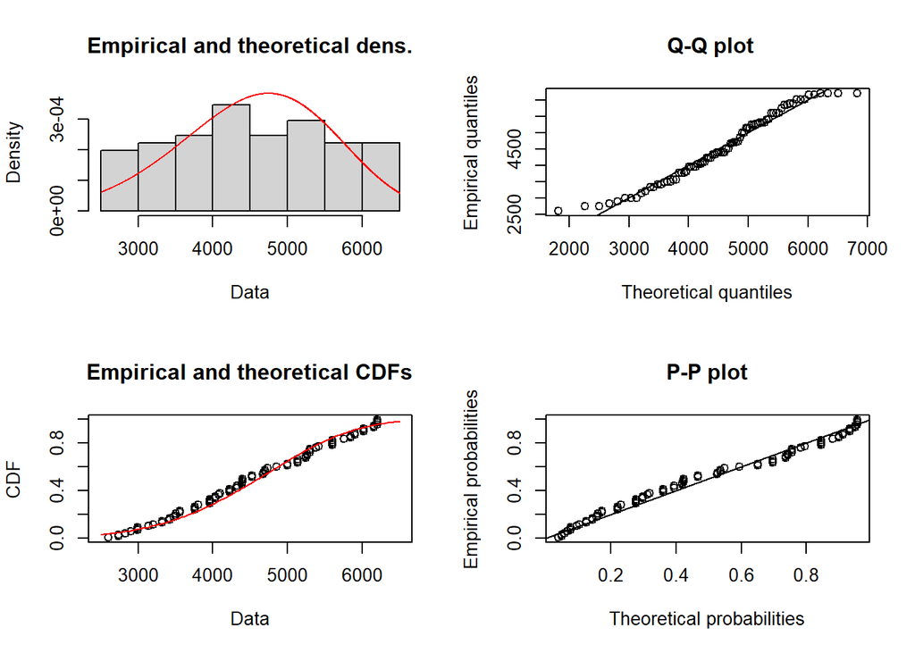

```r
plot(fit_wei_mle)
```

Now we do the same for all other methods and distributions

## Weibull with mme

For the moment matching estimation method we need the moment order of the parameters and a moment function and the `actuar` library for the weibull distribution.

```r
library(actuar)
memp <- function(x, order) mean(x^order)
fit_wei_mme = fitdist(time_rep, 'weibull', method='mme', order=c(1,2), memp=memp)
summary(fit_wei_mme)
```

```
## Fitting of the distribution ' weibull ' by matching moments
## Parameters :
##          estimate
## shape    5.427175
## scale 4937.411574
## Loglikelihood:  -676.4702   AIC:  1356.94   BIC:  1361.729
```

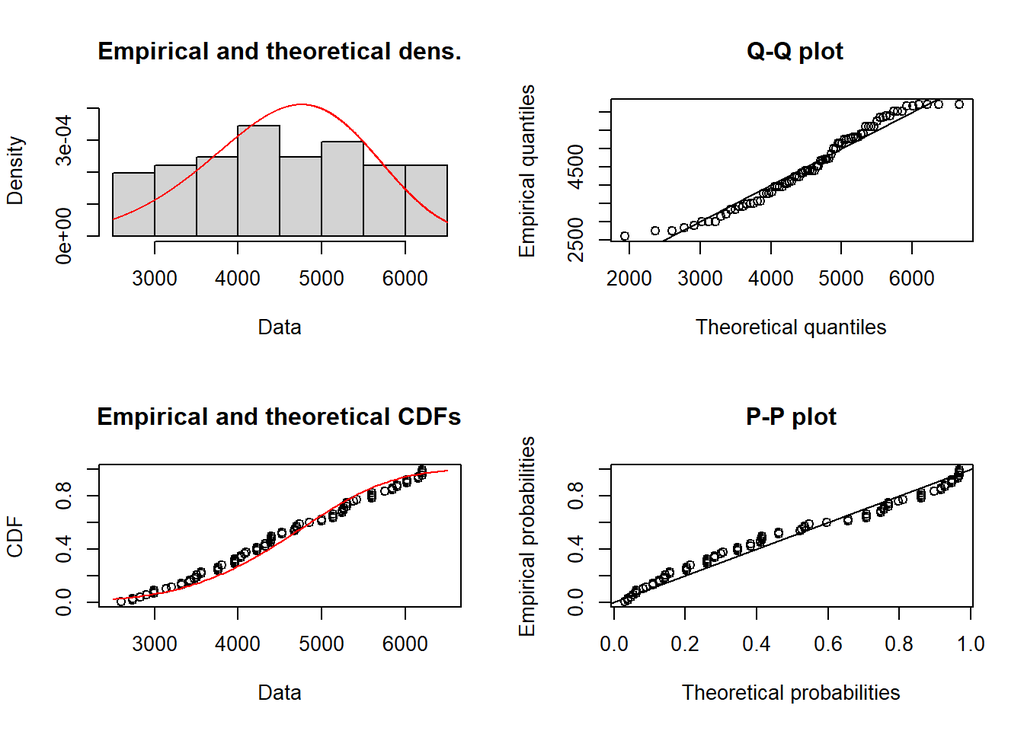

```r
plot(fit_wei_mme)
```

```r
info_df[2, ] = c('weibull','MME',fit_wei_mme$loglik, fit_wei_mme$aic)
```

```r
fit_wei_qme = fitdist(time_rep, 'weibull', method='qme', probs=c(0.5,0.5))
summary(fit_wei_qme)
```

```
## Fitting of the distribution ' weibull ' by matching quantiles
## Parameters :
##        estimate
## shape  438.1094
## scale 4403.6829
## Loglikelihood:  -Inf   AIC:  Inf   BIC:  Inf
```

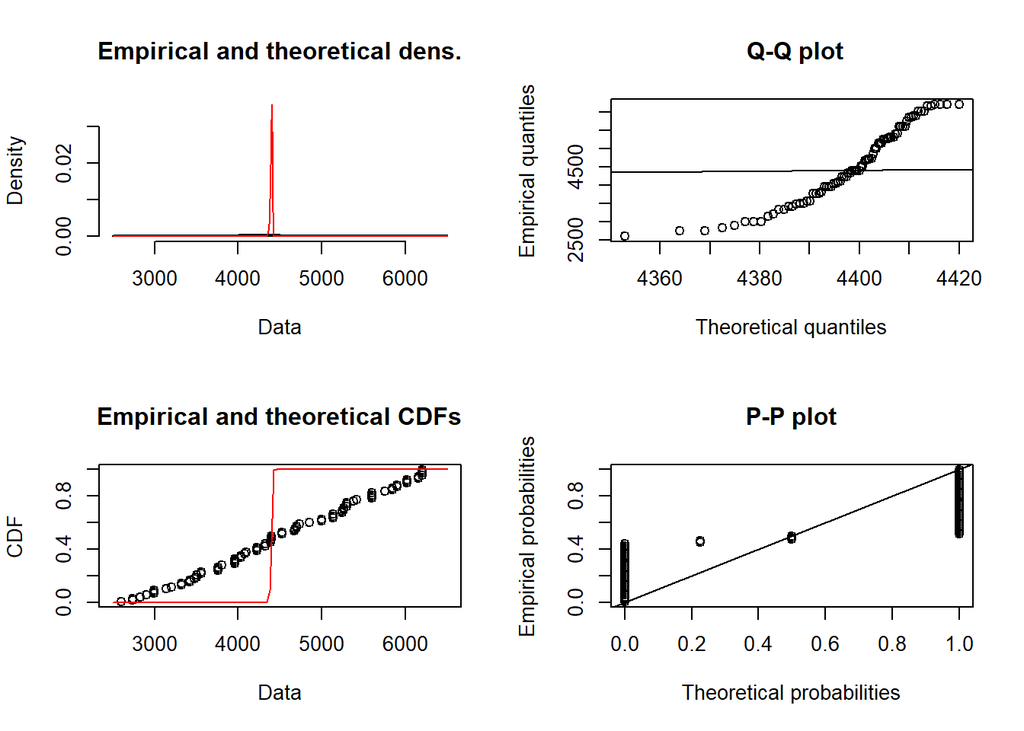

```r
plot(fit_wei_qme)
```

```r
info_df[3, ] = c('weibull','QME',fit_wei_qme$loglik, fit_wei_qme$aic)
```

```r
fit_wei_mge = fitdist(time_rep, 'weibull', method='mge', gof='KS')
summary(fit_wei_mge)
```

```
## Fitting of the distribution ' weibull ' by maximum goodness-of-fit
## Parameters :
##          estimate
## shape    4.532556
## scale 4948.803508
## Loglikelihood:  -676.8732   AIC:  1357.746   BIC:  1362.535
```

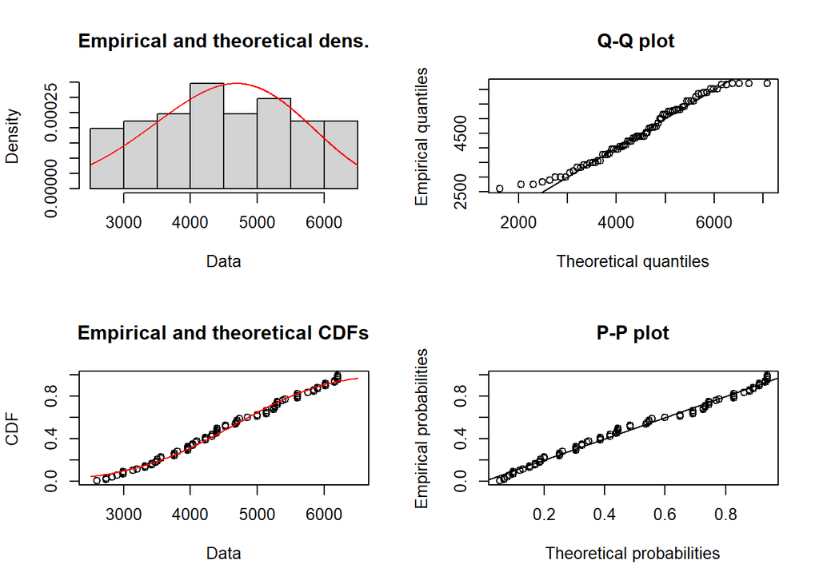

```r
plot(fit_wei_mge)
```

```r
info_df[4, ] = c('weibull','MGE KS',fit_wei_mge$loglik, fit_wei_mge$aic)
```

## Weibull with gme (CvM)

```r
fit_wei_mge.2 = fitdist(time_rep, 'weibull', method='mge', gof='CvM')
summary(fit_wei_mge.2)
```

```
## Fitting of the distribution ' weibull ' by maximum goodness-of-fit
## Parameters :
##          estimate
## shape    4.396707
## scale 4959.679089
## Loglikelihood:  -677.3987   AIC:  1358.797   BIC:  1363.586
```

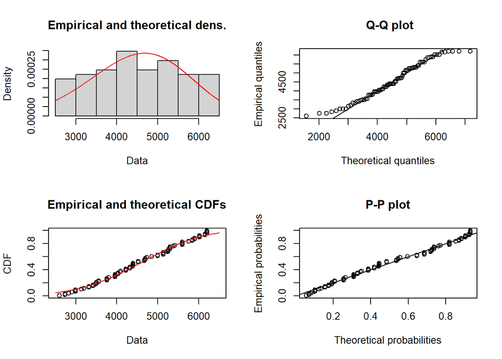

```r
plot(fit_wei_mge.2)
```

```r
info_df[5, ] = c('weibull','MGE CvM',fit_wei_mge.2$loglik, fit_wei_mge.2$aic)
```

## Weibull with gme (AD)

```r
fit_wei_mge.3 = fitdist(time_rep, 'weibull', method='mge', gof='AD')
summary(fit_wei_mge.3)
```

```
## Fitting of the distribution ' weibull ' by maximum goodness-of-fit
## Parameters :
##          estimate
## shape    4.594402
## scale 4957.845560
## Loglikelihood:  -676.7169   AIC:  1357.434   BIC:  1362.223
```

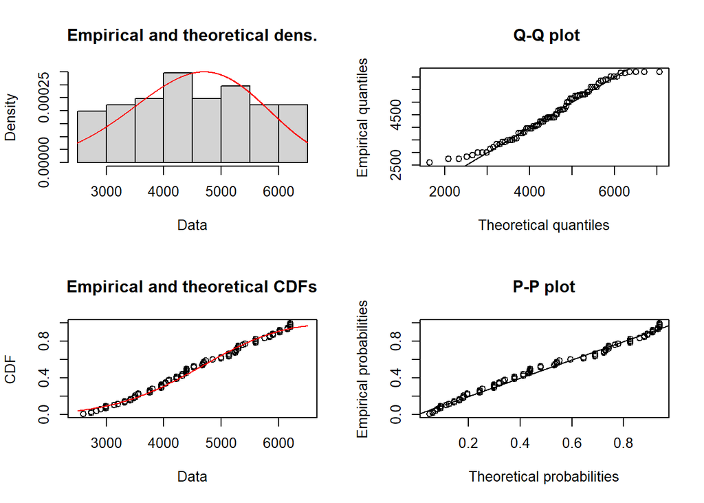

```r
plot(fit_wei_mge.3)
```

```r
info_df[6, ] = c('weibull','MGE AD',fit_wei_mge.3$loglik, fit_wei_mge.3$aic)
```

Now we can do this whole process for the other 3 distributions.

# Gamma Distribution

```r
# MLE
fit_gam_mle = fitdist(time_rep, 'gamma', method='mle')
summary(fit_gam_mle)
```

```
## Fitting of the distribution ' gamma ' by maximum likelihood
## Parameters :
##           estimate   Std. Error
## shape 18.631105968 1.4131941195
## rate   0.004102318 0.0002951511
## Loglikelihood:  -677.1205   AIC:  1358.241   BIC:  1363.03
## Correlation matrix:
##          shape     rate
## shape 1.000000 0.942279
## rate  0.942279 1.000000
```

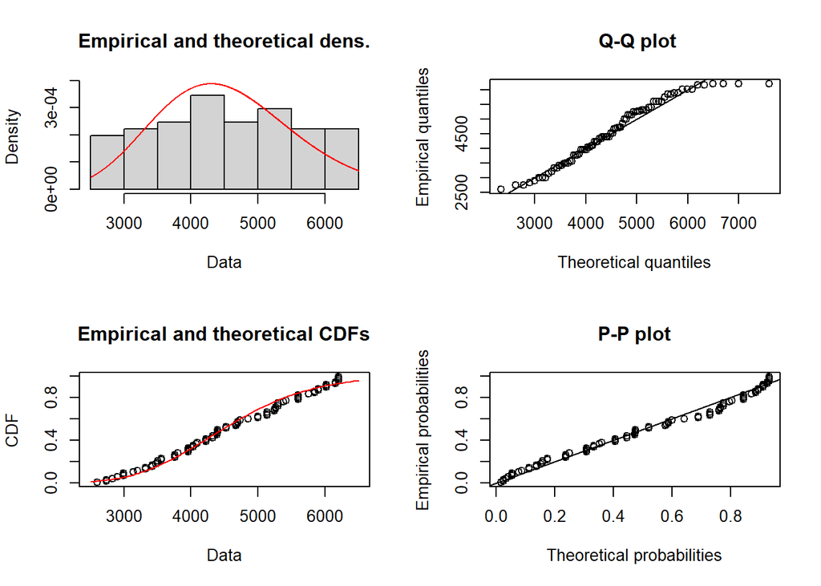

```r
plot(fit_gam_mle)
```

```r
info_df[7, ] = c('gamma','MLE',fit_gam_mle$loglik, fit_gam_mle$aic)

# MME
fit_gam_mme = fitdist(time_rep, 'gamma', method='mme')
summary(fit_gam_mme)
```

```
## Fitting of the distribution ' gamma ' by matching moments
## Parameters :
##           estimate
## shape 19.566003065
## rate   0.004307935
## Loglikelihood:  -677.1708   AIC:  1358.342   BIC:  1363.131
```

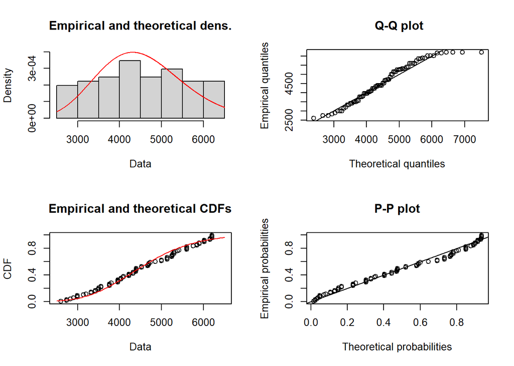

```r
plot(fit_gam_mme)
```

```r
info_df[8, ] = c('gamma','MME',fit_gam_mme$loglik, fit_gam_mme$aic)

# QME
fit_gam_qme = fitdist(time_rep, 'gamma', method='qme', probs=c(0.5,0.5))
summary(fit_gam_qme)
```

```
## Fitting of the distribution ' gamma ' by matching quantiles
## Parameters :
##           estimate
## shape 19.779435058
## rate   0.004419803
## Loglikelihood:  -677.3719   AIC:  1358.744   BIC:  1363.533
```

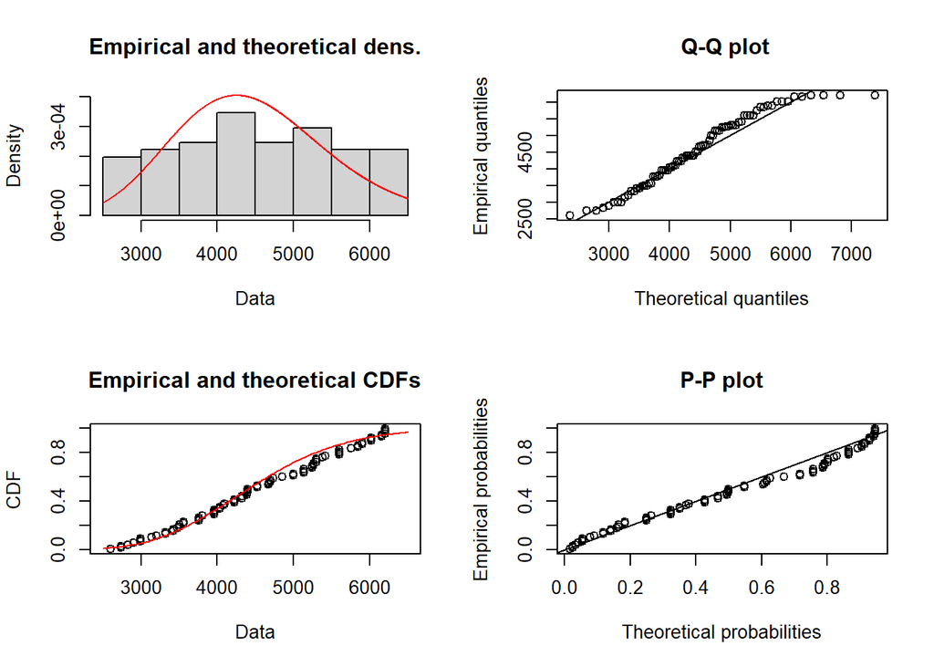

```r
plot(fit_gam_qme)
```

```r
info_df[9, ] = c('gamma','QME',fit_gam_qme$loglik, fit_gam_qme$aic)

# MGE
fit_gam_mge = fitdist(time_rep, 'gamma', method='mge', gof='KS')
summary(fit_gam_mge)
```

```
## Fitting of the distribution ' gamma ' by maximum goodness-of-fit
## Parameters :
##           estimate
## shape 18.930539010
## rate   0.004101269
## Loglikelihood:  -677.3246   AIC:  1358.649   BIC:  1363.438
```

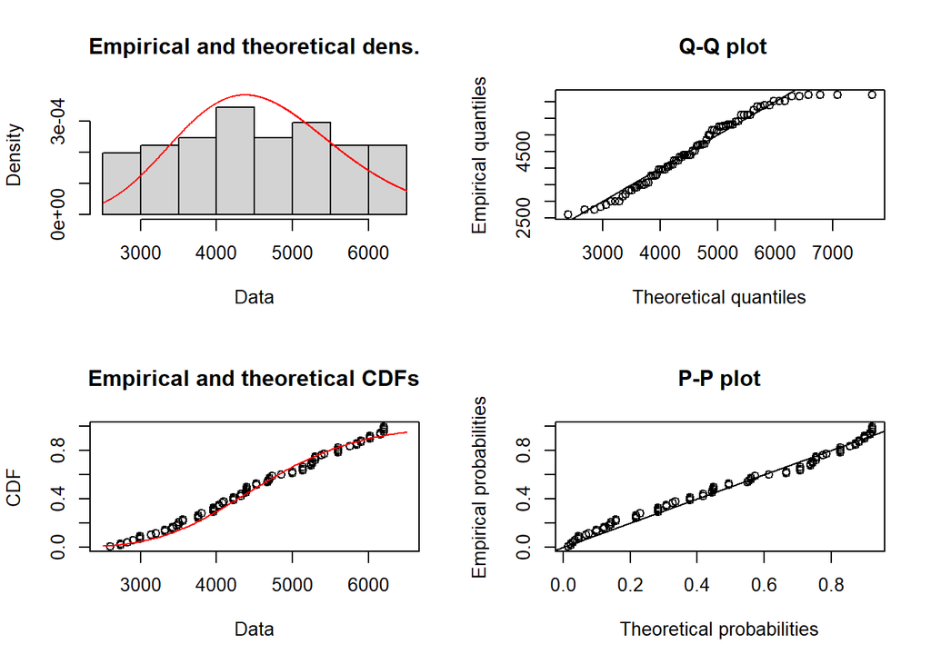

```r
plot(fit_gam_mge)
```

```r
info_df[10, ] = c('gamma','MGE KS',fit_gam_mge$loglik, fit_gam_mge$aic)

fit_gam_mge.3 = fitdist(time_rep, 'gamma', method='mge', gof='AD')
summary(fit_gam_mge.3)
```

```
## Fitting of the distribution ' gamma ' by maximum goodness-of-fit
## Parameters :
##           estimate
## shape 15.864804577
## rate   0.003462223
## Loglikelihood:  -677.6759   AIC:  1359.352   BIC:  1364.141
```

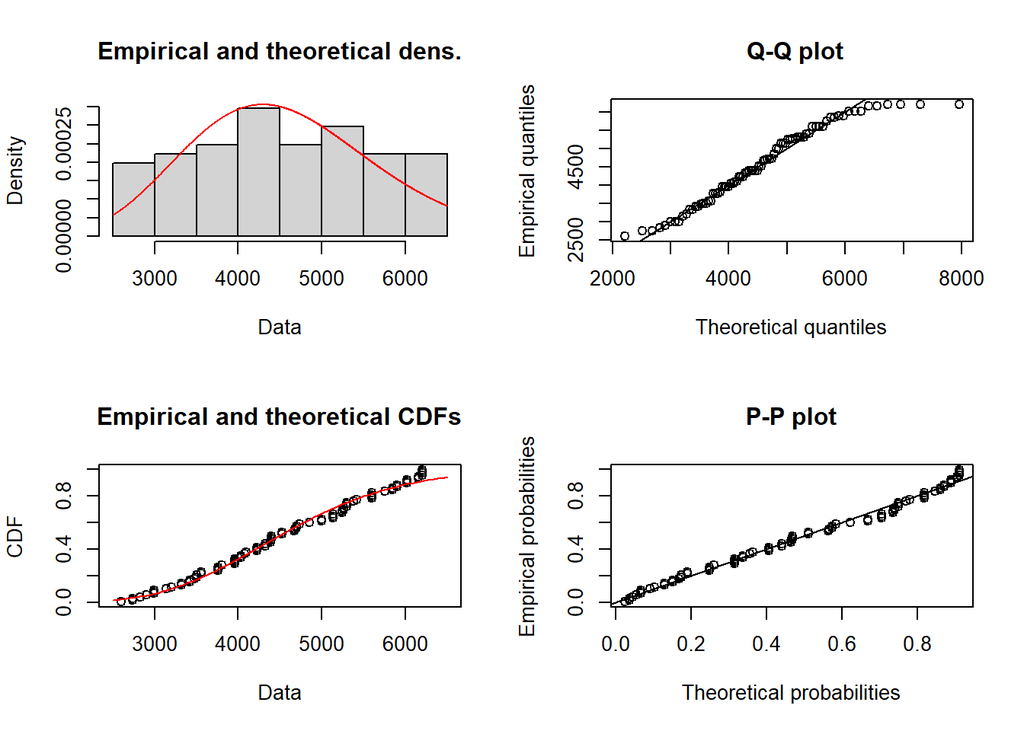

```r
plot(fit_gam_mge.3)
```

```r
info_df[11, ] = c('gamma','MGE AD',fit_gam_mge.3$loglik, fit_gam_mge.3$aic)
```

The only exception here, is that when we use CvM goodness-of-fit distance it cannot perform the optimization process and returns and error. Therefore it is not mentioned here.

# Log-normal Distribution

```r
# MLE
fit_lnorm_mle = fitdist(time_rep, 'lnorm', method='mle')
summary(fit_lnorm_mle)
```

```
## Fitting of the distribution ' lnorm ' by maximum likelihood
## Parameters :
##          estimate Std. Error
## meanlog 8.3940114 0.02629605
## sdlog   0.2366644 0.01859262
## Loglikelihood:  -678.1189   AIC:  1360.238   BIC:  1365.027
## Correlation matrix:
##         meanlog sdlog
## meanlog       1     0
## sdlog         0     1
```

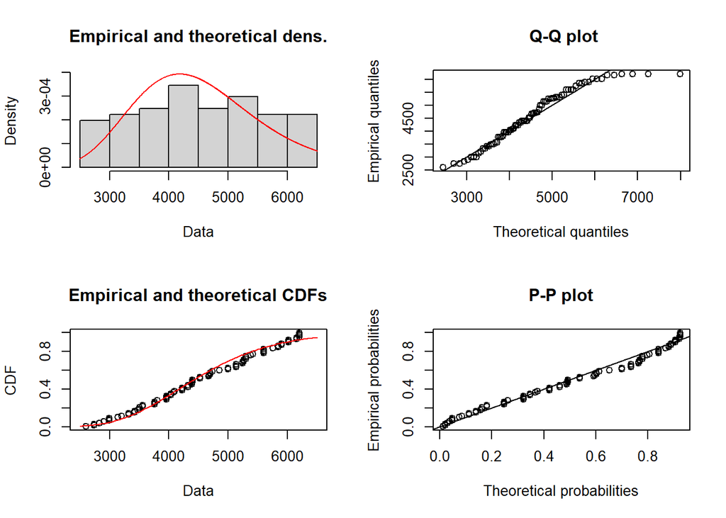

```r
plot(fit_lnorm_mle)
```

```r
info_df[12, ] = c('lnorm','MLE',fit_lnorm_mle$loglik, fit_lnorm_mle$aic)

# MME
fit_lnorm_mme = fitdist(time_rep, 'lnorm', method='mme')
summary(fit_lnorm_mme)
```

```
## Fitting of the distribution ' lnorm ' by matching moments
## Parameters :
##          estimate
## meanlog 8.3961672
## sdlog   0.2232618
## Loglikelihood:  -678.409   AIC:  1360.818   BIC:  1365.607
```

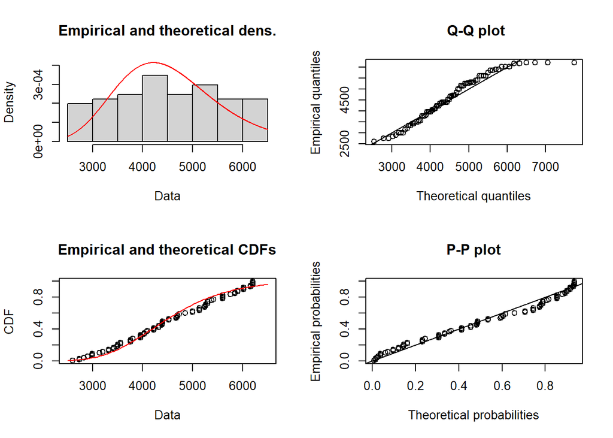

```r
plot(fit_lnorm_mme)
```

```r
info_df[13, ] = c('lnorm','MME',fit_lnorm_mme$loglik, fit_lnorm_mme$aic)

# QME
fit_lnorm_qme = fitdist(time_rep, 'lnorm', method='qme', probs=c(0.5,0.5))
summary(fit_lnorm_qme)
```

```
## Fitting of the distribution ' lnorm ' by matching quantiles
## Parameters :
##         estimate
## meanlog 8.389359
## sdlog   1.646213
## Loglikelihood:  -795.563   AIC:  1595.126   BIC:  1599.915
```

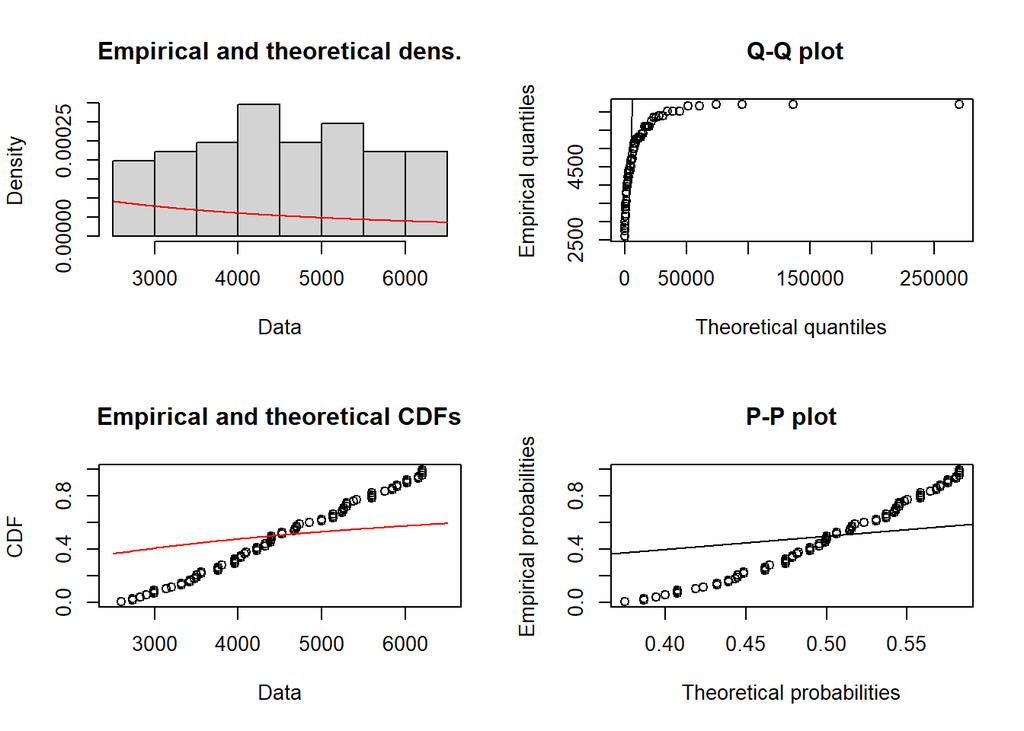

```r
plot(fit_lnorm_qme)
```

```r
info_df[14, ] = c('lnorm','QME',fit_lnorm_qme$loglik, fit_lnorm_qme$aic)

# MGE
fit_lnorm_mge = fitdist(time_rep, 'lnorm', method='mge', gof='KS')
summary(fit_lnorm_mge)
```

```
## Fitting of the distribution ' lnorm ' by maximum goodness-of-fit
## Parameters :
##          estimate
## meanlog 8.4140086
## sdlog   0.2297221
## Loglikelihood:  -678.499   AIC:  1360.998   BIC:  1365.787
```

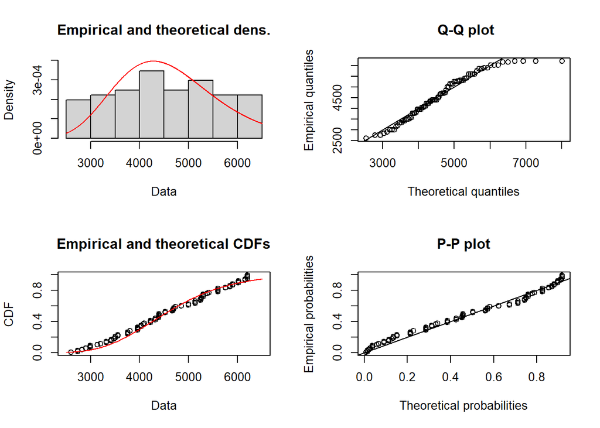

```r
plot(fit_lnorm_mge)
```

```r
info_df[15, ] = c('lnorm','MGE KS',fit_lnorm_mge$loglik, fit_lnorm_mge$aic)

fit_lnorm_mge.2 = fitdist(time_rep, 'lnorm', method='mge', gof='CvM')
summary(fit_lnorm_mge.2)
```

```
## Fitting of the distribution ' lnorm ' by maximum goodness-of-fit
## Parameters :
##         estimate
## meanlog 8.407460
## sdlog   0.260755
## Loglikelihood:  -678.9409   AIC:  1361.882   BIC:  1366.671
```

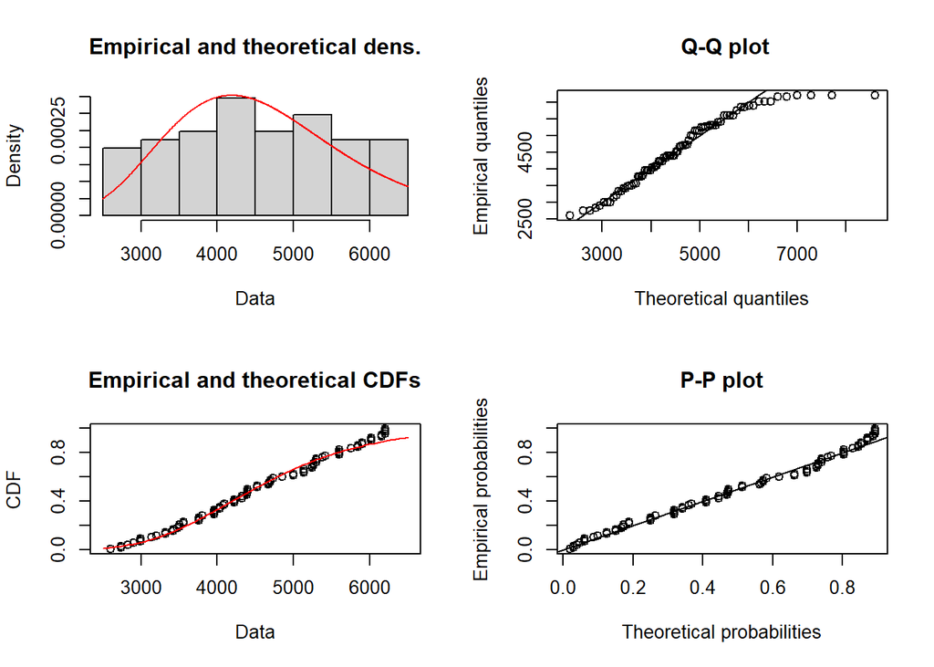

```r
plot(fit_lnorm_mge.2)
```

```r
info_df[16, ] = c('lnorm','MGE CvM',fit_lnorm_mge.2$loglik, fit_lnorm_mge.2$aic)

fit_lnorm_mge.3 = fitdist(time_rep, 'lnorm', method='mge', gof='AD')
summary(fit_lnorm_mge.3)
```

```
## Fitting of the distribution ' lnorm ' by maximum goodness-of-fit
## Parameters :
##          estimate
## meanlog 8.4023157
## sdlog   0.2557703
## Loglikelihood:  -678.6255   AIC:  1361.251   BIC:  1366.04
```

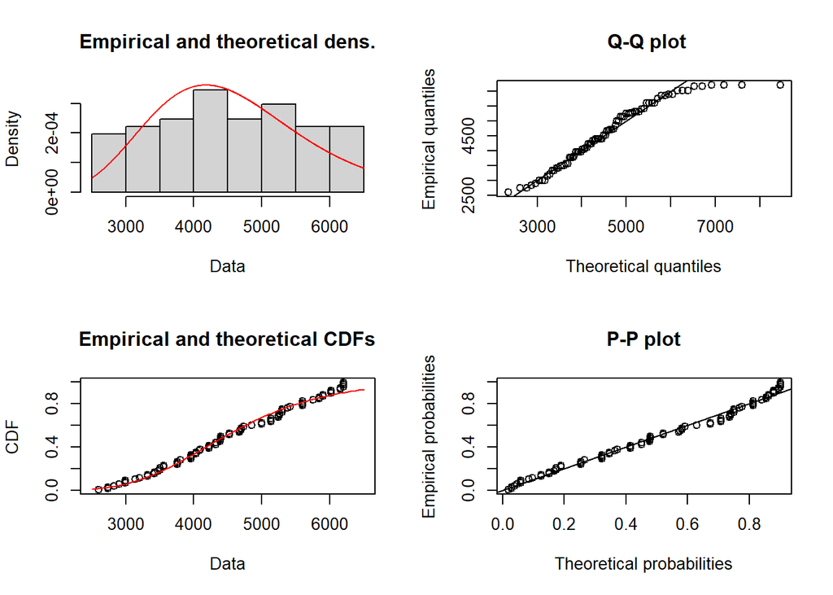

```r
plot(fit_lnorm_mge.3)
```

```r
info_df[17, ] = c('lnorm','MGE AD',fit_lnorm_mge.3$loglik, fit_lnorm_mge.3$aic)
```

# Beta Distribution

For the beta distribution we need to make some adjustments since this distribution needs our data to be within [0-1] interval. We can achieve this by simply dividing our time points to 10000.

```r
time_rep_beta = time_rep/10000
```

Now we can check different methods for this distribution.

```r
# MLE
fit_beta_mle = fitdist(time_rep_beta, 'beta', method='mle')
summary(fit_beta_mle)
```

```
## Fitting of the distribution ' beta ' by maximum likelihood
## Parameters :
##        estimate Std. Error
## shape1 10.42913   1.618280
## shape2 12.53879   1.953533
## Loglikelihood:  70.36095   AIC:  -136.7219   BIC:  -131.933
## Correlation matrix:
##           shape1    shape2
## shape1 1.0000000 0.9570843
## shape2 0.9570843 1.0000000
```

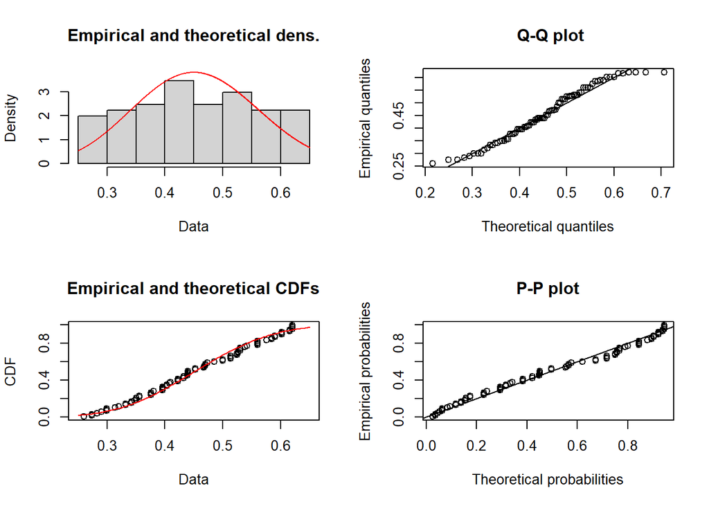

```r
plot(fit_beta_mle)
```

```r
info_df[18, ] = c('beta','MLE',fit_beta_mle$loglik, fit_beta_mle$aic)

# MME
fit_beta_mme = fitdist(time_rep_beta, 'beta', method='mme')
summary(fit_beta_mme)
```

```
## Fitting of the distribution ' beta ' by matching moments
## Parameters :
##        estimate
## shape1 10.22523
## shape2 12.28812
## Loglikelihood:  70.35271   AIC:  -136.7054   BIC:  -131.9165
```

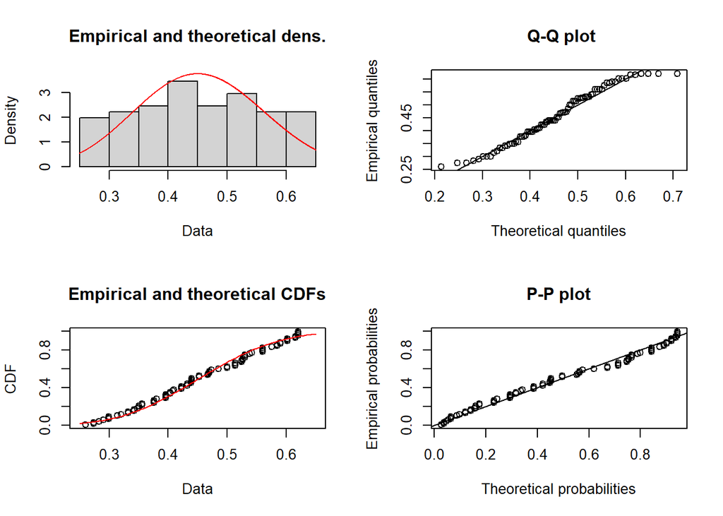

```r
plot(fit_beta_mme)
```

```r
info_df[19, ] = c('beta','MME',fit_beta_mme$loglik, fit_beta_mme$aic)

# QME
fit_beta_qme = fitdist(time_rep_beta, 'beta', method='qme', probs=c(0.5,0.5))
summary(fit_beta_qme)
```

```
## Fitting of the distribution ' beta ' by matching quantiles
## Parameters :
##        estimate
## shape1 10.07660
## shape2 12.73491
## Loglikelihood:  69.76598   AIC:  -135.532   BIC:  -130.7431
```

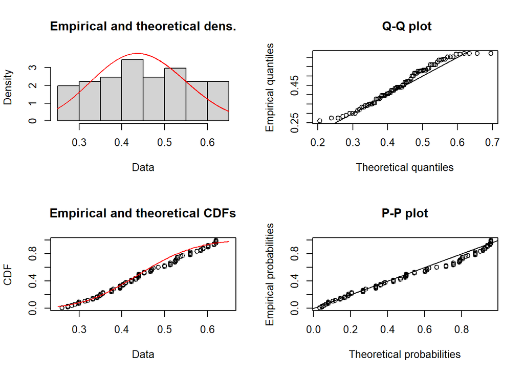

```r
plot(fit_beta_qme)
```

```r
info_df[20, ] = c('beta','QME',fit_beta_qme$loglik, fit_beta_qme$aic)

# MGE
fit_beta_mge = fitdist(time_rep_beta, 'beta', method='mge', gof='KS')
summary(fit_beta_mge)
```

```
## Fitting of the distribution ' beta ' by maximum goodness-of-fit
## Parameters :
##         estimate
## shape1  9.682916
## shape2 11.462186
## Loglikelihood:  70.17136   AIC:  -136.3427   BIC:  -131.5538
```

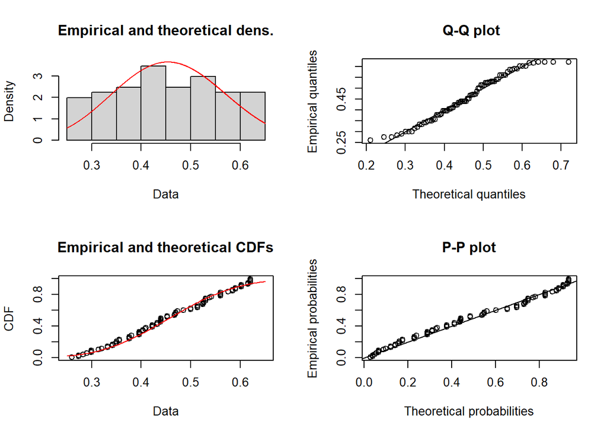

```r
plot(fit_beta_mge)
```

```r
info_df[21, ] = c('beta','MGE KS',fit_beta_mge$loglik, fit_beta_mge$aic)

fit_beta_mge.2 = fitdist(time_rep_beta, 'beta', method='mge', gof='CvM')
summary(fit_beta_mge.2)
```

```
## Fitting of the distribution ' beta ' by maximum goodness-of-fit
## Parameters :
##        estimate
## shape1 8.159664
## shape2 9.765756
## Loglikelihood:  69.16045   AIC:  -134.3209   BIC:  -129.532
```

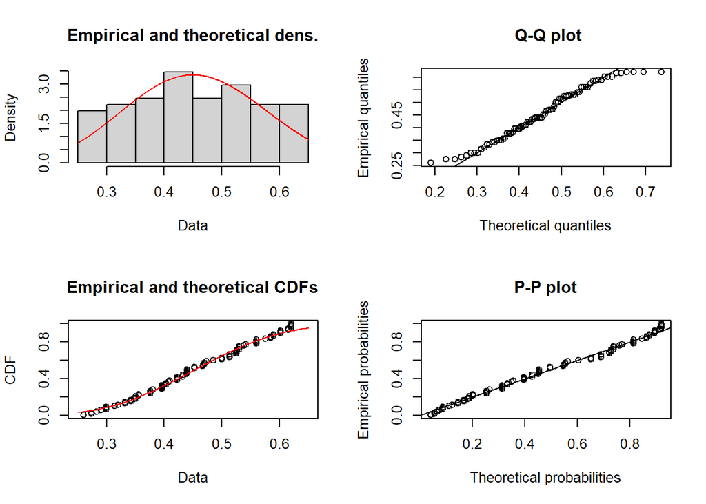

```r
plot(fit_beta_mge.2)
```

```r
info_df[22, ] = c('beta','MGE CvM',fit_beta_mge.2$loglik, fit_beta_mge.2$aic)

fit_beta_mge.3 = fitdist(time_rep_beta, 'beta', method='mge', gof='AD')
summary(fit_beta_mge.3)
```

```
## Fitting of the distribution ' beta ' by maximum goodness-of-fit
## Parameters :
##         estimate
## shape1  8.811117
## shape2 10.552354
## Loglikelihood:  69.77768   AIC:  -135.5554   BIC:  -130.7665
```

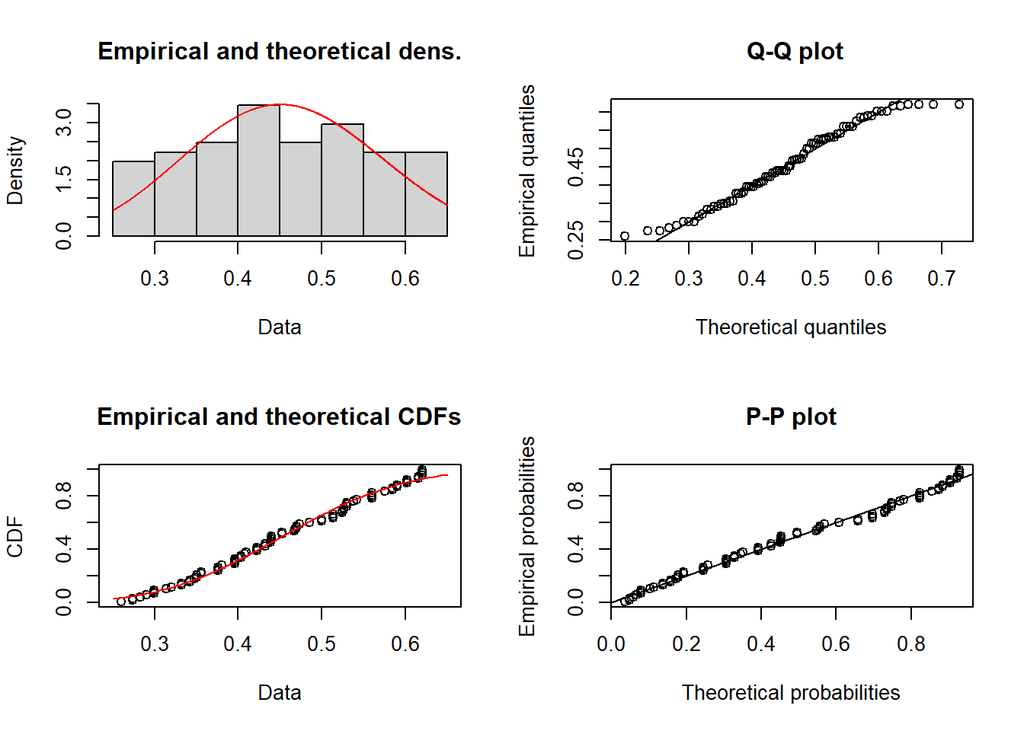

```r
plot(fit_beta_mge.3)
```

```r
info_df[23, ] = c('beta','MGE AD',fit_beta_mge.3$loglik, fit_beta_mge.3$aic)
```

Now that we have stored all the required information in the `info_df` data frame, we can simply output it to compare different methods and different distributions.

```r
info_df
```

```
##      model  method    Log_likelihood               AIC
## 1  weibull     MLE -676.061536677565  1356.12307335513
## 2  weibull     MME -676.470245152428  1356.94049030486
## 3  weibull     QME              -Inf               Inf
## 4  weibull  MGE KS -676.873218426897  1357.74643685379
## 5  weibull MGE CvM -677.398714292767  1358.79742858553
## 6  weibull  MGE AD -676.716917205346  1357.43383441069
## 7    gamma     MLE -677.120495531521  1358.24099106304
## 8    gamma     MME -677.170847404212  1358.34169480842
## 9    gamma     QME  -677.37189722724  1358.74379445448
## 10   gamma  MGE KS -677.324584961779  1358.64916992356
## 11   gamma  MGE AD -677.675910149545  1359.35182029909
## 12   lnorm     MLE  -678.11887033624  1360.23774067248
## 13   lnorm     MME -678.408955720256  1360.81791144051
## 14   lnorm     QME  -795.56298527765   1595.1259705553
## 15   lnorm  MGE KS -678.499011074008  1360.99802214802
## 16   lnorm MGE CvM -678.940854637379  1361.88170927476
## 17   lnorm  MGE AD -678.625467685866  1361.25093537173
## 18    beta     MLE  70.3609460813251  -136.72189216265
## 19    beta     MME  70.3527073931769 -136.705414786354
## 20    beta     QME  69.7659828778352  -135.53196575567
## 21    beta  MGE KS  70.1713563475903 -136.342712695181
## 22    beta MGE CvM   69.160448279479 -134.320896558958
## 23    beta  MGE AD  69.7776809239453 -135.555361847891
```

To interpret the results, We need to find the distribution with highest log-likelihood value and lowest aic value. As you can see, the best distribution is beta with maximum likelihood estimation method.

Here you can see this distribution fit again which estimates the parameters

```r
fit_beta_mle
```

```
## Fitting of the distribution ' beta ' by maximum likelihood
## Parameters:
##        estimate Std. Error
## shape1 10.42913   1.618280
## shape2 12.53879   1.953533
```

The `fitdistrplus` package also has a function called `descdist` that can check different distributions fitness to our data which as you can see gives the same results.

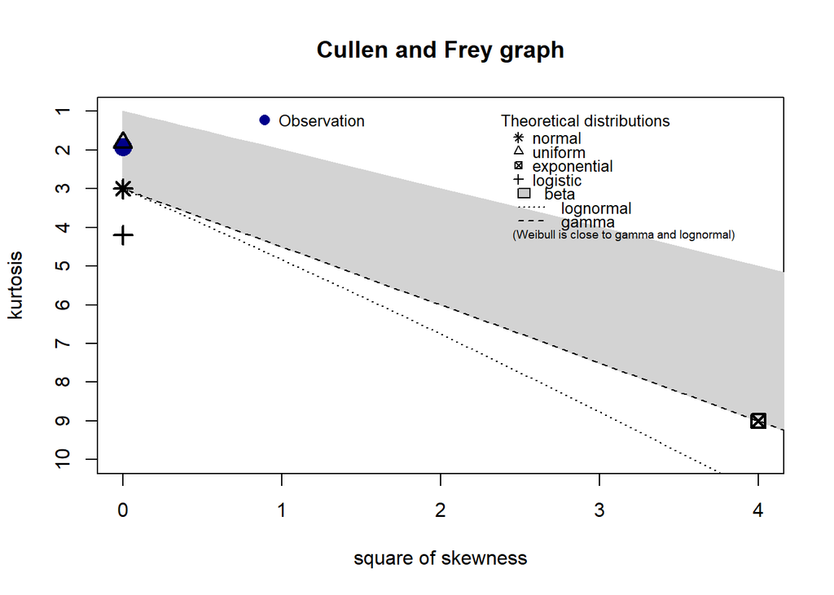

```
## summary statistics
## ------
## min:  2600   max:  6200
## median:  4400
## mean:  4541.852
## estimated sd:  1033.188
## estimated skewness:  -0.03387739
## estimated kurtosis:  1.918159
```

```r
descdist(time_rep)
```

Therefore our chosen model is the beta distribution with parameters 10.4291315 as shape1, and 12.5387915 as shape2.

## Failure Probability and Reliability

Failure probability and reliability are complimentary of each other, as $R(t) = 1 - F(t)$. Therefore, 5% failure probability equals 95% reliability and vice versa. In order to find the 5% failure probability we can use the `qbeta` function to find the quantile of the optimal beta distribution that produces 5% failure probability or is reliable 95% of the time.

```r
fail_quant = qbeta(0.05, fit_beta_mle$estimate[1], fit_beta_mle$estimate[2])
```

Remember that with beta distribution, we divided the time points to 10000. We can now multiply this number to reach the time point that produces 95% reliability.

Therefore:

```r
fail_quant = fail_quant*10000
fail_quant
```

```
## [1] 2887.646
```

Therefore at 2887.65 hours, 95% of the systems are still working.